# Retail Shoppers Intention Data Analysis

Joan Mwangi

7/3/2021

```r
knitr::opts_chunk$set(error = TRUE)
```

# Problem Definition

*Kira Plastinina is a fashion retail store located in China,Russia, Belarus, Ukraine, Philippines, Kazakhstan, Armenia and Ukraine mostly targeting ladies between 15 - 25 years.*

*My goal as a data analyst is to get meaningful insights of customers behavioral patterns and behavior using data collected within the past one year.*

# Data Sourcing

- The dataset consists of 10 numerical and 8 categorical attributes.
- The ‘Revenue’ attribute will be used as the class label.

  > The following is a breakdown of the data set’s variables:
  > - “Administrative”, “Administrative Duration”, “Informational”, “Informational Duration”, “Product Related” and “Product Related Duration” represents the number of different types of pages visited by the visitor in that session and total time spent in each of these page categories. The values of these features are derived from the URL information of the pages visited by the user and updated in real-time when a user takes an action, e.g. moving from one page to another.
  > - The “Bounce Rate”, “Exit Rate” and “Page Value” features represent the metrics measured by “Google Analytics” for each page in the e-commerce site.
  > - The value of the “Bounce Rate” feature for a web page refers to the percentage of visitors who enter the site from that page and then leave (“bounce”) without triggering any other requests to the analytics server during that session.
  > - The value of the “Exit Rate” feature for a specific web page is calculated as for all page views to the page, the percentage that was the last in the session.
  > - The “Page Value” feature represents the average value for a web page that a user visited before completing an e-commerce transaction.
  > - The “Special Day” feature indicates the closeness of the site visiting time to a specific special day (e.g. Mother’s Day, Valentine’s Day) in which the sessions are more likely to be finalized with the transaction. The value of this attribute is determined by considering the dynamics of e-commerce such as the duration between the order date and delivery date. For example, for Valentine’s day, this value takes a nonzero value between February 2 and February 12, zero before and after this date unless it is close to another special day, and its maximum value of 1 on February 8.
  > - The dataset also includes the operating system, browser, region, traffic type, visitor type as returning or new visitor, a Boolean value indicating whether the date of the visit is weekend, and month of the year.

# Check the Data

### Loading the dataset

```r
online <- read.csv("C:/Users/jojos/Downloads/online_shoppers_intention.csv")
head(online)#previewing the fist 6 rows
```

```
##   Administrative Administrative_Duration Informational Informational_Duration
## 1              0                       0             0                      0
## 2              0                       0             0                      0
## 3              0                      -1             0                     -1
## 4              0                       0             0                      0
## 5              0                       0             0                      0
## 6              0                       0             0                      0
##   ProductRelated ProductRelated_Duration BounceRates ExitRates PageValues
## 1              1                0.000000  0.20000000 0.2000000          0
## 2              2               64.000000  0.00000000 0.1000000          0
## 3              1               -1.000000  0.20000000 0.2000000          0
## 4              2                2.666667  0.05000000 0.1400000          0
## 5             10              627.500000  0.02000000 0.0500000          0
## 6             19              154.216667  0.01578947 0.0245614          0
##   SpecialDay Month OperatingSystems Browser Region TrafficType
## 1          0   Feb                1       1      1           1
## 2          0   Feb                2       2      1           2
## 3          0   Feb                4       1      9           3
## 4          0   Feb                3       2      2           4
## 5          0   Feb                3       3      1           4
## 6          0   Feb                2       2      1           3
##         VisitorType Weekend Revenue
## 1 Returning_Visitor   FALSE   FALSE
## 2 Returning_Visitor   FALSE   FALSE
## 3 Returning_Visitor   FALSE   FALSE
## 4 Returning_Visitor   FALSE   FALSE
## 5 Returning_Visitor    TRUE   FALSE
## 6 Returning_Visitor   FALSE   FALSE
```

### Checking the dimensions of the dataset

```r
dim(online)
```

```
## [1] 12330    18
```

*There are 12330 observations and 18 dimensions

### Checking the datatype

```r
str(online)
```

```
## 'data.frame':    12330 obs. of  18 variables:
##  $ Administrative         : int  0 0 0 0 0 0 0 1 0 0 ...
##  $ Administrative_Duration: num  0 0 -1 0 0 0 -1 -1 0 0 ...
##  $ Informational          : int  0 0 0 0 0 0 0 0 0 0 ...
##  $ Informational_Duration : num  0 0 -1 0 0 0 -1 -1 0 0 ...
##  $ ProductRelated         : int  1 2 1 2 10 19 1 1 2 3 ...
##  $ ProductRelated_Duration: num  0 64 -1 2.67 627.5 ...
##  $ BounceRates            : num  0.2 0 0.2 0.05 0.02 ...
##  $ ExitRates              : num  0.2 0.1 0.2 0.14 0.05 ...
##  $ PageValues             : num  0 0 0 0 0 0 0 0 0 0 ...
##  $ SpecialDay             : num  0 0 0 0 0 0 0.4 0 0.8 0.4 ...
##  $ Month                  : chr  "Feb" "Feb" "Feb" "Feb" ...
##  $ OperatingSystems       : int  1 2 4 3 3 2 2 1 2 2 ...
##  $ Browser                : int  1 2 1 2 3 2 4 2 2 4 ...
##  $ Region                 : int  1 1 9 2 1 1 3 1 2 1 ...
##  $ TrafficType            : int  1 2 3 4 4 3 3 5 3 2 ...
##  $ VisitorType            : chr  "Returning_Visitor" "Returning_Visitor" "Returning_Visitor" "Returning_Visitor" ...
##  $ Weekend                : logi  FALSE FALSE FALSE FALSE TRUE FALSE ...
##  $ Revenue                : logi  FALSE FALSE FALSE FALSE FALSE FALSE ...
```

### Viewing the class of the dataset

```r
class(online)
```

```
## [1] "data.frame"
```

*The dataset belongs to the data frame class*

# Perform Data Cleaning

### Checking for duplicates

```r
duplicates <- online[duplicated(online),]
dim(duplicates)
```

```
## [1] 119  18
```

- There are 119 duplicates

#### Removing duplicates

```r
new_online <- online[-which(duplicated(online)),]
dim(new_online)
```

```
## [1] 12211    18
```

### Checking for null values

```r
colSums(is.na(new_online))
```

```
##          Administrative Administrative_Duration           Informational
##                      12                      12                      12
##  Informational_Duration          ProductRelated ProductRelated_Duration
##                      12                      12                      12
##             BounceRates               ExitRates              PageValues
##                      12                      12                       0
##              SpecialDay                   Month        OperatingSystems
##                       0                       0                       0
##                 Browser                  Region             TrafficType
##                       0                       0                       0
##             VisitorType                 Weekend                 Revenue
##                       0                       0                       0
```

- Filling null values with mode

```r
#first loading the library
library(tidyr)
```

```r
gettingmode <- function(x){uniqx <- unique(x)
uniqx[which.max(tabulate(match(x,uniqx)))]}
```

```r
#using the mode function to fill in the missing values
new_online[is.na(new_online)] <- gettingmode(new_online[!is.na(new_online)])
#confirming if they have been filled
colSums(is.na(new_online))
```

```
##          Administrative Administrative_Duration           Informational
##                       0                       0                       0
##  Informational_Duration          ProductRelated ProductRelated_Duration
##                       0                       0                       0
##             BounceRates               ExitRates              PageValues
##                       0                       0                       0
##              SpecialDay                   Month        OperatingSystems
##                       0                       0                       0
##                 Browser                  Region             TrafficType
##                       0                       0                       0
##             VisitorType                 Weekend                 Revenue
##                       0                       0                       0
```

# Perform Exploratory Data Analysis

Viewing the data type of each column in order to assess which type plots to visualize

```r
sapply(new_online,class)
```

```
##          Administrative Administrative_Duration           Informational
##             "character"             "character"             "character"
##  Informational_Duration          ProductRelated ProductRelated_Duration
##             "character"             "character"             "character"
##             BounceRates               ExitRates              PageValues
##             "character"             "character"               "numeric"
##              SpecialDay                   Month        OperatingSystems
##               "numeric"             "character"               "integer"
##                 Browser                  Region             TrafficType
##               "integer"               "integer"               "integer"
##             VisitorType                 Weekend                 Revenue
##             "character"               "logical"               "logical"
```

## Univariate Analysis

### Measures of central tendency and dispersion

```r
summary(new_online)
```

```
##  Administrative     Administrative_Duration Informational
##  Length:12211       Length:12211            Length:12211
##  Class :character   Class :character        Class :character
##  Mode  :character   Mode  :character        Mode  :character
##
##
##
##  Informational_Duration ProductRelated     ProductRelated_Duration
##  Length:12211           Length:12211       Length:12211
##  Class :character       Class :character   Class :character
##  Mode  :character       Mode  :character   Mode  :character
##
##
##
##  BounceRates         ExitRates           PageValues        SpecialDay
##  Length:12211       Length:12211       Min.   :  0.000   Min.   :0.00000
##  Class :character   Class :character   1st Qu.:  0.000   1st Qu.:0.00000
##  Mode  :character   Mode  :character   Median :  0.000   Median :0.00000
##                                        Mean   :  5.947   Mean   :0.06191
##                                        3rd Qu.:  0.000   3rd Qu.:0.00000
##                                        Max.   :361.764   Max.   :1.00000
##     Month           OperatingSystems    Browser           Region
##  Length:12211       Min.   :1.000    Min.   : 1.000   Min.   :1.000
##  Class :character   1st Qu.:2.000    1st Qu.: 2.000   1st Qu.:1.000
##  Mode  :character   Median :2.000    Median : 2.000   Median :3.000
##                     Mean   :2.124    Mean   : 2.358   Mean   :3.153
##                     3rd Qu.:3.000    3rd Qu.: 2.000   3rd Qu.:4.000
##                     Max.   :8.000    Max.   :13.000   Max.   :9.000
##   TrafficType     VisitorType         Weekend         Revenue
##  Min.   : 1.000   Length:12211       Mode :logical   Mode :logical
##  1st Qu.: 2.000   Class :character   FALSE:9352      FALSE:10303
##  Median : 2.000   Mode  :character   TRUE :2859      TRUE :1908
##  Mean   : 4.074
##  3rd Qu.: 4.000
##  Max.   :20.000
```

### Histograms

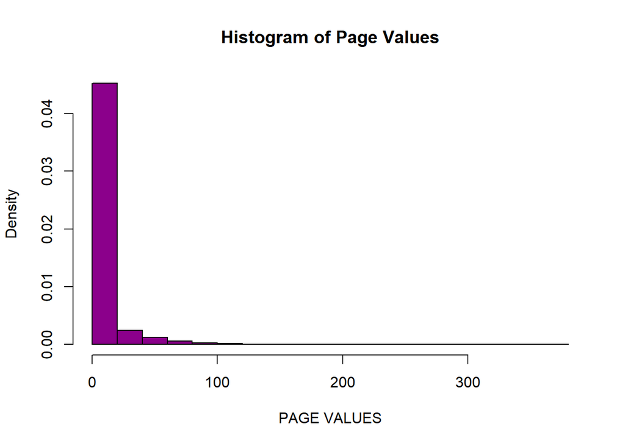

```r
#histogram of page values
 hist(new_online$PageValues,
     main= "Histogram of Page Values",
     xlab="PAGE VALUES",col="darkmagenta",freq=FALSE)
```

*Majority of the average page values visited by the user are around 0*

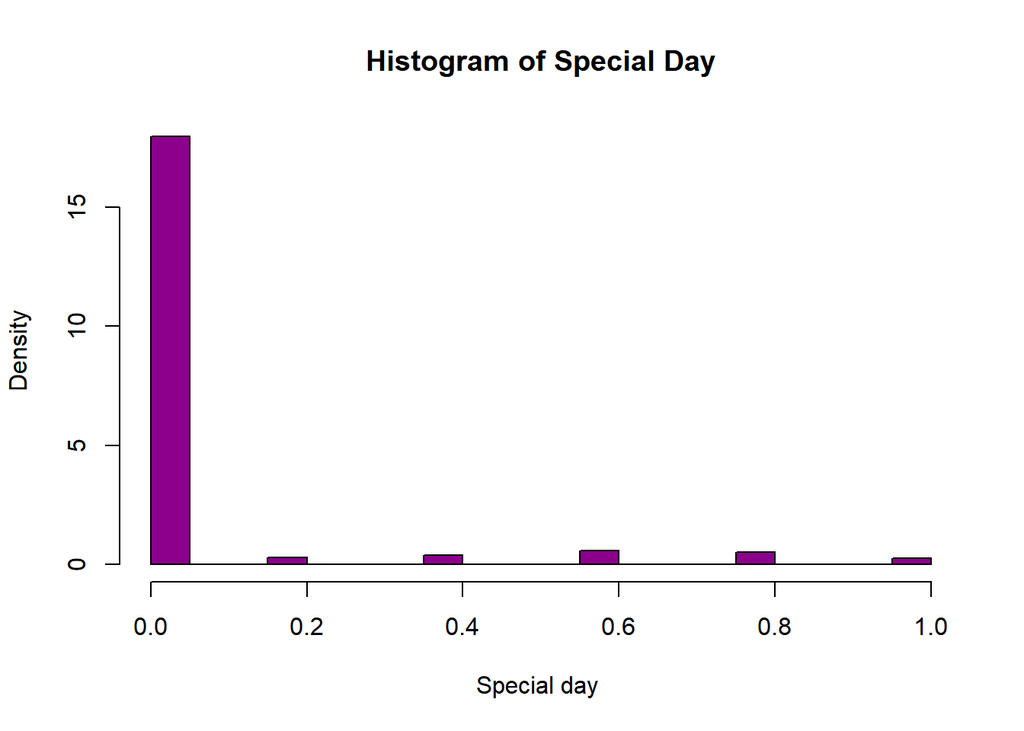

```r
#histogram of administrative duration
 h <- hist(new_online$SpecialDay,
     main= "Histogram of Special Day",
     xlab="Special day ",col="darkmagenta",freq=FALSE)
```

*According to the histogram, majority of the users didn’t visit the site during special days*

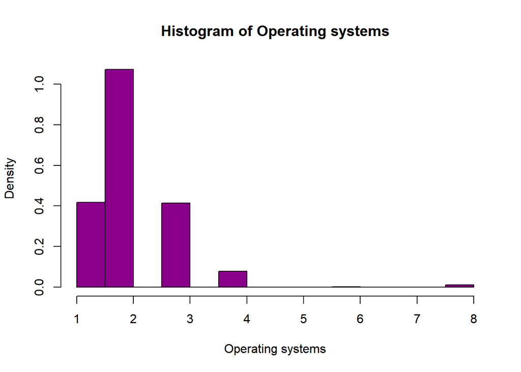

```r
#histogram of administrative
 hist(new_online$OperatingSystems,
     main= "Histogram of Operating systems",
     xlab="Operating systems",col="darkmagenta",freq=FALSE)
```

*Majority of the operating systems were within a value of 2*

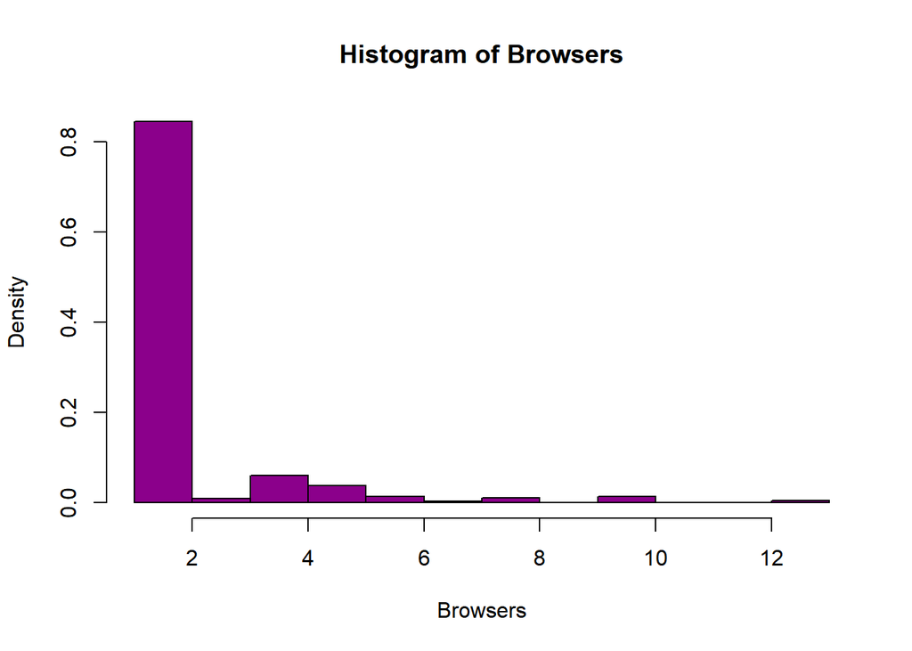

```r
#histogram of administratuve
 hist(new_online$Browser,
     main= "Histogram of Browsers",
     xlab="Browsers",col="darkmagenta",freq=FALSE)
```

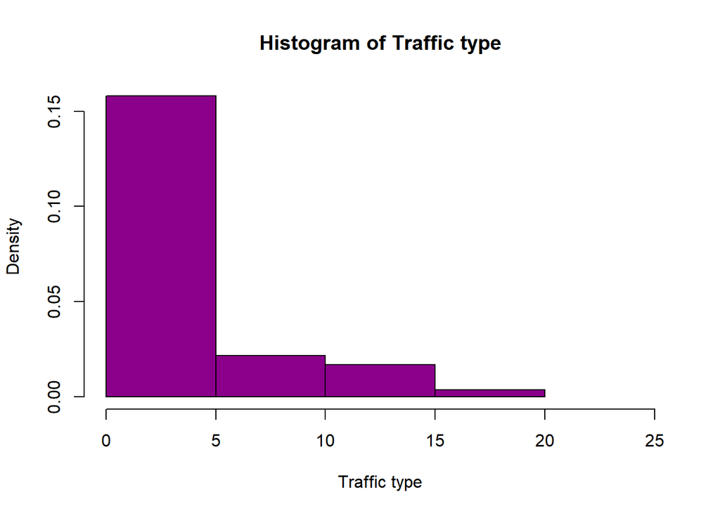

```r
#histogram of administratuve
 hist(new_online$TrafficType,
     main= "Histogram of Traffic type",
     xlab="Traffic type",breaks=4,col="darkmagenta",xlim=c(0,25),freq=FALSE)
```

*Majority of the values within the traffic type is between 0 and 5*

### Bar plots

```
## 6 columns ignored with more than 50 categories.
## Administrative_Duration: 3337 categories
## Informational_Duration: 1260 categories
## ProductRelated: 312 categories
## ProductRelated_Duration: 9553 categories
## BounceRates: 1873 categories
## ExitRates: 4778 categories
```

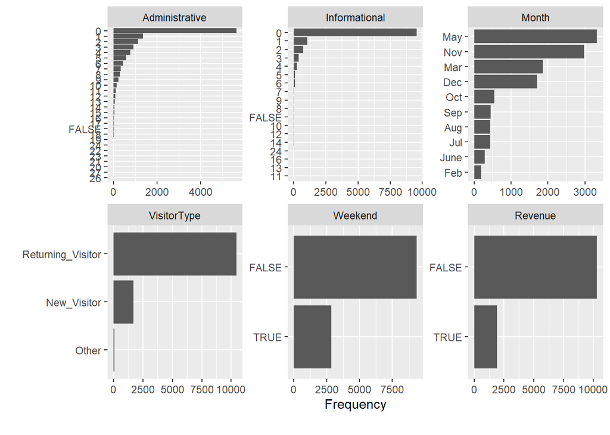

```r
plot_bar(new_online)
```

From the bar plots we can see that;

```
-   both administrative and informational columns, they had the highest frequency at 0.

-   The Month of May had the highest records followed by November.

-   Returning visitor had the highest record of over 10,000

-   Weekend type False had the highest record same case as Revenue variable
```

## Bi-variate Analysis

### Correlation Matrix

```r
        #install.packages("corrplot")
        library(corrplot)
        correlation <- round(cor(new_online[,c(9,10,12,13,14,15)]),2)
        correlation
```

```
##                  PageValues SpecialDay OperatingSystems Browser Region
## PageValues             1.00      -0.06             0.02    0.05   0.01
## SpecialDay            -0.06       1.00             0.01    0.00  -0.02
## OperatingSystems       0.02       0.01             1.00    0.21   0.07
## Browser                0.05       0.00             0.21    1.00   0.09
## Region                 0.01      -0.02             0.07    0.09   1.00
## TrafficType            0.01       0.05             0.18    0.10   0.04
##                  TrafficType
## PageValues              0.01
## SpecialDay              0.05
## OperatingSystems        0.18
## Browser                 0.10
## Region                  0.04
## TrafficType             1.00
```

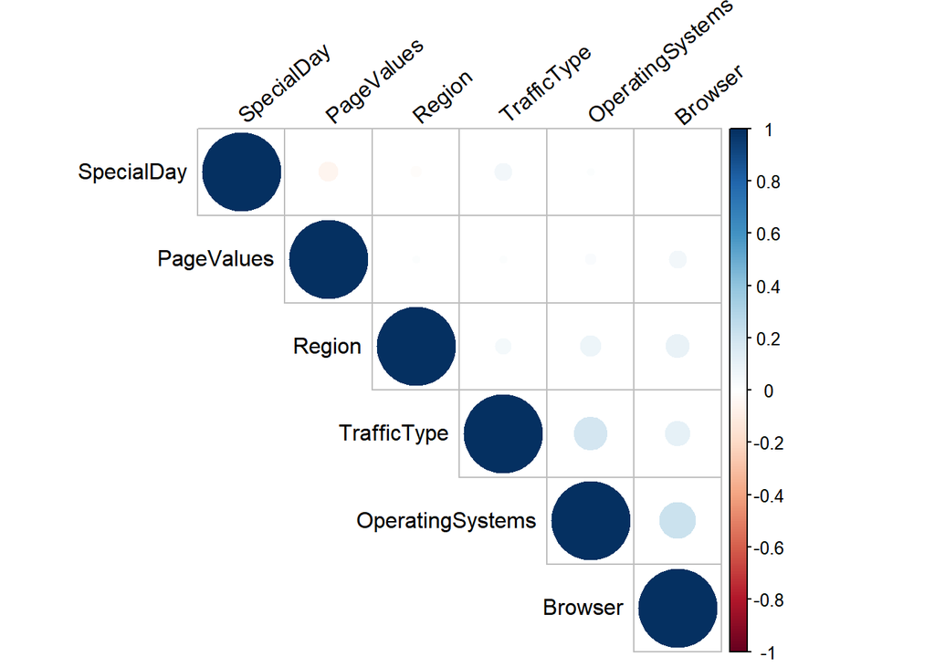

```r
        corrplot(correlation,type="upper",order="hclust",tl.col="black",tl.srt=40)
```

The correlation matrix show that:

- Browser and operating systems are positively correlated with a value of 0.21
- Traffic type and operating system with 0.18
- Traffic type and browser with 0.1
- Region and browser with 0.09
- Region and operating system with 0.07

# Implementing the Solution

# Feature engineering

### Data Pre processing

```r
#install.packages("caret")
install.packages("lattice")
```

```
## Error in contrib.url(repos, "source"): trying to use CRAN without setting a mirror
```

```r
install.packages("ggplot2")
```

```
## Error in contrib.url(repos, "source"): trying to use CRAN without setting a mirror
```

```r
library(caret)
#transforming the logical variables

new_online$Revenue <- as.numeric(new_online$Revenue)
new_online$Weekend <- as.numeric(new_online$Weekend)
head(new_online)
```

```
##   Administrative Administrative_Duration Informational Informational_Duration
## 1              0                       0             0                      0
## 2              0                       0             0                      0
## 3              0                      -1             0                     -1
## 4              0                       0             0                      0
## 5              0                       0             0                      0
## 6              0                       0             0                      0
##   ProductRelated ProductRelated_Duration BounceRates   ExitRates PageValues
## 1              1                       0         0.2         0.2          0
## 2              2                      64           0         0.1          0
## 3              1                      -1         0.2         0.2          0
## 4              2             2.666666667        0.05        0.14          0
## 5             10                   627.5        0.02        0.05          0
## 6             19             154.2166667 0.015789474 0.024561404          0
##   SpecialDay Month OperatingSystems Browser Region TrafficType
## 1          0   Feb                1       1      1           1
## 2          0   Feb                2       2      1           2
## 3          0   Feb                4       1      9           3
## 4          0   Feb                3       2      2           4
## 5          0   Feb                3       3      1           4
## 6          0   Feb                2       2      1           3
##         VisitorType Weekend Revenue
## 1 Returning_Visitor       0       0
## 2 Returning_Visitor       0       0
## 3 Returning_Visitor       0       0
## 4 Returning_Visitor       0       0
## 5 Returning_Visitor       1       0
## 6 Returning_Visitor       0       0
```

### Label Encoding

```r
library(CatEncoders)
  encode <- LabelEncoder.fit(new_online$VisitorType)
  new_online$VisitorType <- transform(encode, new_online$VisitorType)

 encode <- LabelEncoder.fit(new_online$Month)
  new_online$Month <- transform(encode, new_online$Month)
print(unique(new_online$Month))
```

```
##  [1]  3  6  7  9  5  4  1  8 10  2
```

```r
print(unique(new_online$VisitorType))
```

```
## [1] 3 1 2
```

### scaling the dataset

[output not shown]

## Computing the kmeans clustering in r

```r
set.seed(123)
#setting revenue as online.class

online.class <- new_online[,18]
online_kmeans <- kmeans(online.norm,centers=3,nstart=25)

print(online_kmeans)
```

```
## K-means clustering with 3 clusters of sizes 7910, 1947, 2354
##
## Cluster means:
##   PageValues   SpecialDay        Month OperatingSystems     Browser
## 1 -0.2296726  0.046029435 -0.046225823      0.002415036  0.01201498
## 2  1.2178683 -0.194876601  0.185245070     -0.031649819  0.05723088
## 3 -0.2355476  0.006513131  0.002113045      0.018062559 -0.08770900
##         Region  TrafficType VisitorType     Weekend   Revenue
## 1  0.006840132  0.003821330  0.07400639 -0.55288785 -0.430318
## 2 -0.026055444 -0.010503236 -0.23869756  0.05960292  2.268508
## 3 -0.001433940 -0.004153323 -0.05125166  1.80853696 -0.430318
##
## Clustering vector:
##     1     2     3     4     5     6     7     8     9    10    11    12    13
##     1     1     1     1     3     1     1     3     1     1     1     1     1
```

[output cut: 1887 more lines]

```r
online_kmeans$size
```

```
## [1] 7910 1947 2354
```

The first cluster has 7910 values, the second cluster has 1947 values and the third cluster has 2354 values

## Visualizing the kmeans clusters

```r
#installing the packages
install.packages("factoextra")
```

```
## Error in contrib.url(repos, "source"): trying to use CRAN without setting a mirror
```

```r
install.packages("NbClust")
```

```
## Error in contrib.url(repos, "source"): trying to use CRAN without setting a mirror
```

```r
library(factoextra)
```

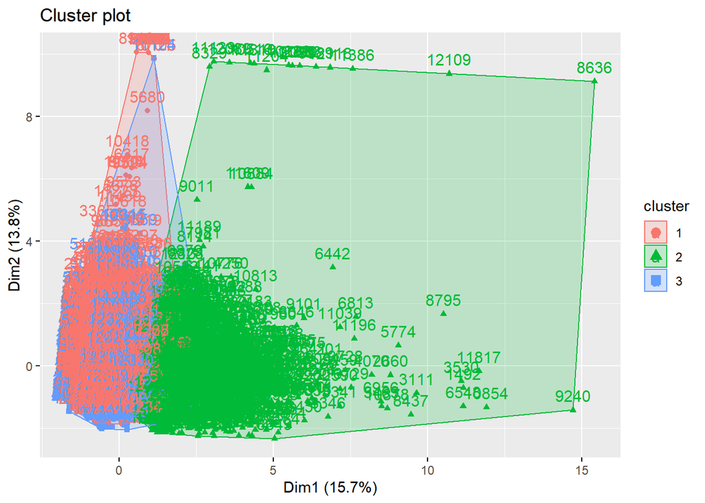

```r
library(NbClust)
library(ggplot2)
fviz_cluster(online_kmeans,data= online.norm)
```

### Determining the optimal number of clusters

### Method 1 : Elbow Method

```r
library(factoextra)
library(NbClust)
library(ggplot2)
```

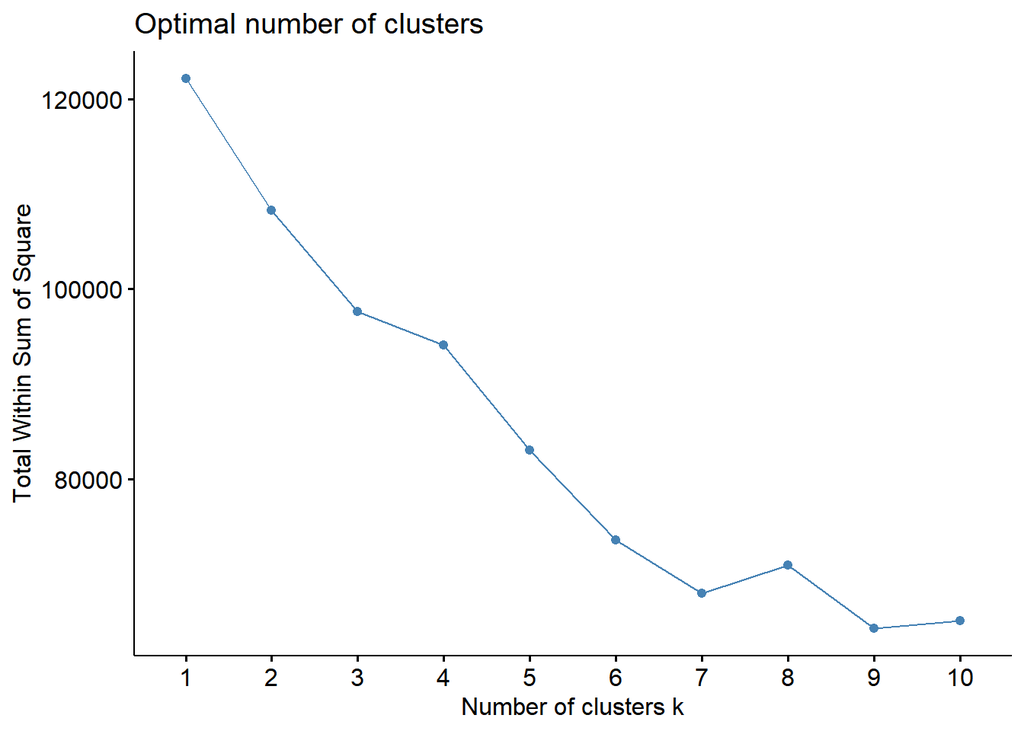

```r
fviz_nbclust(x = online.norm,FUNcluster = kmeans, method = 'wss')
```

the number of clusters using the elbow method is 3

### 2. Silhouette Method

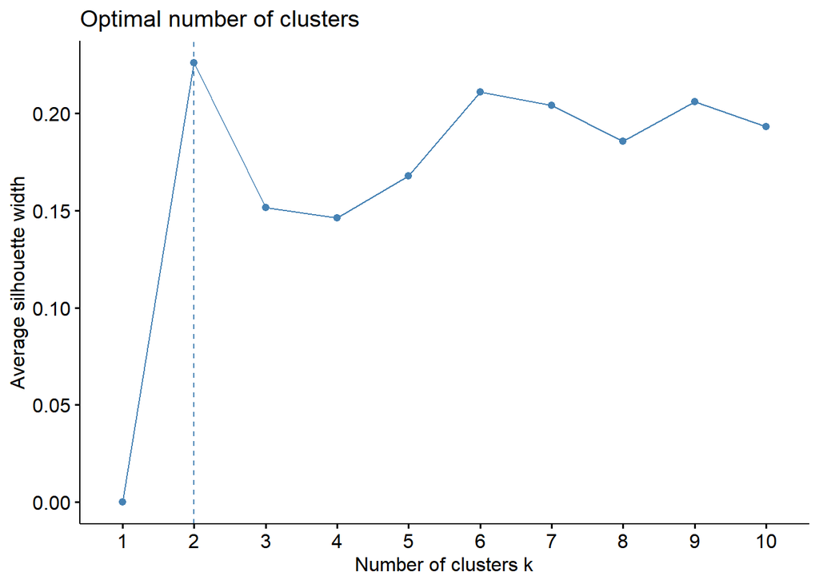

```r
fviz_nbclust(x = online.norm,FUNcluster = kmeans, method = 'silhouette' )
```

Silhouette method suggests that the optimal number of clusters is 2

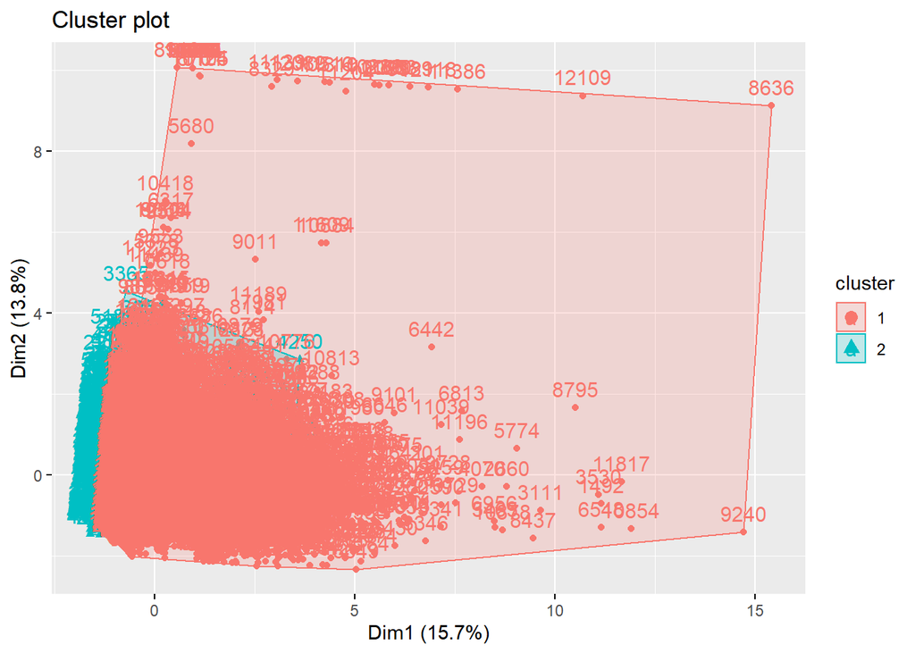

```r
#given that the the biggest joint is at 8, ill set the clusters at 8 and visualize them
online_k2 <- kmeans(online.norm,2)
fviz_cluster(online_k2,online.norm)
```

using 2 clusters suggested by silhouette method didn’t create clear clusters

## Hierarchical clustering

### Identifying hierarchical clustering methods that can identify stronger clustering structures

```r
# Compute distances using euclidean
d <- dist(scale(online.norm), method = "euclidean")
#hierarchical clustering using ward.d2
hc <- hclust(d, method = "ward.D2")
```

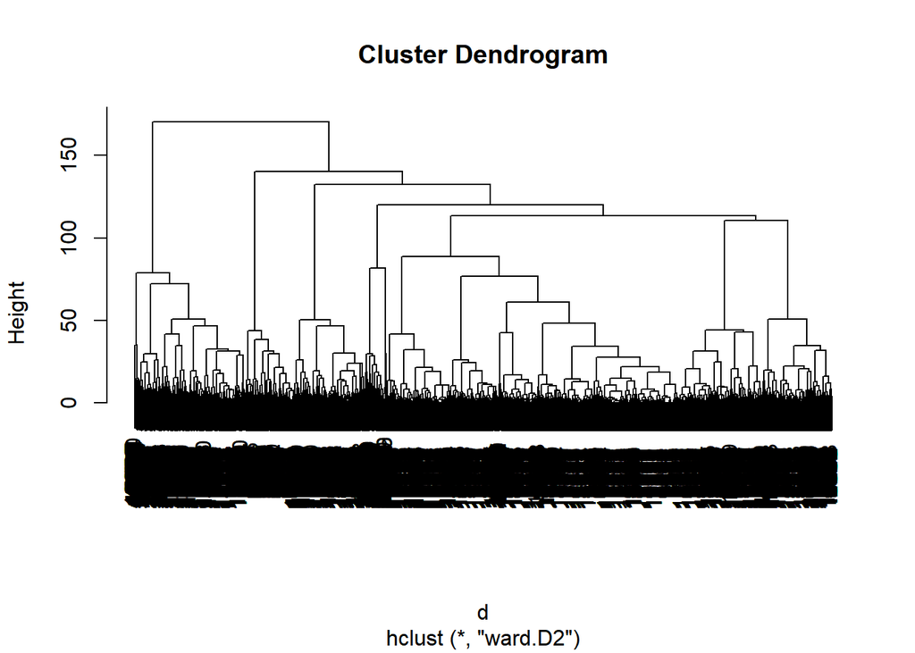

```r
#plotting a dendogram
plot(hc, xlim = c(1, 20), ylim = c(1,8))
```

```r
cut <- cutree(clusters, 6)
```

[output not shown]

```r
table(cut,online.class)
```

[output not shown]

```r
#comparing the results gotten with scaled_online.class
```

## finding the optimal number of clusters

```r
library(NbClust)
library(tidyverse)
library(cluster)
library(factoextra)
library(dendextend)
```

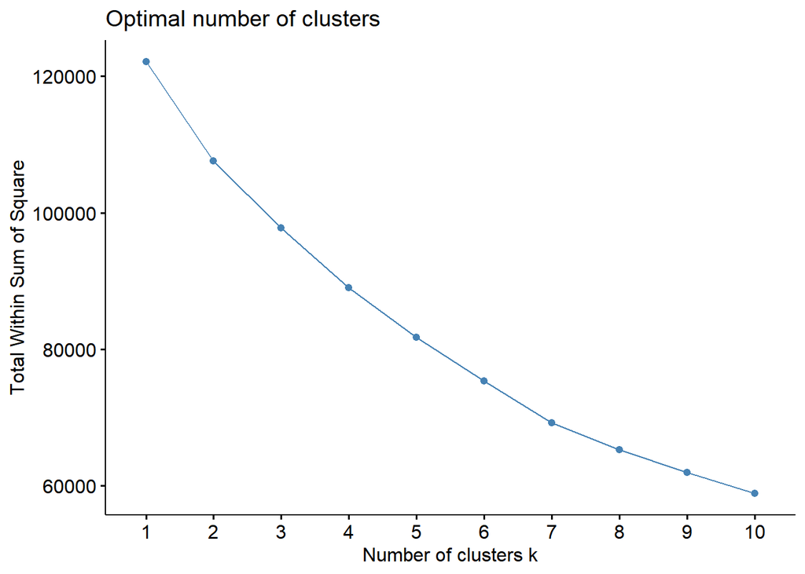

```r
fviz_nbclust(online.norm,FUN = hcut, method="wss")
```

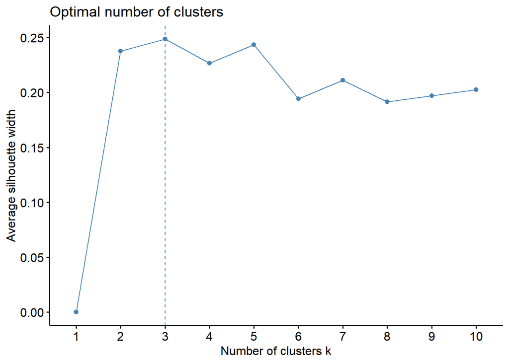

```r
#using silhoutte method to compare the elbow method and silhoutte
fviz_nbclust(online.norm, FUN = hcut, method = "silhouette")
```

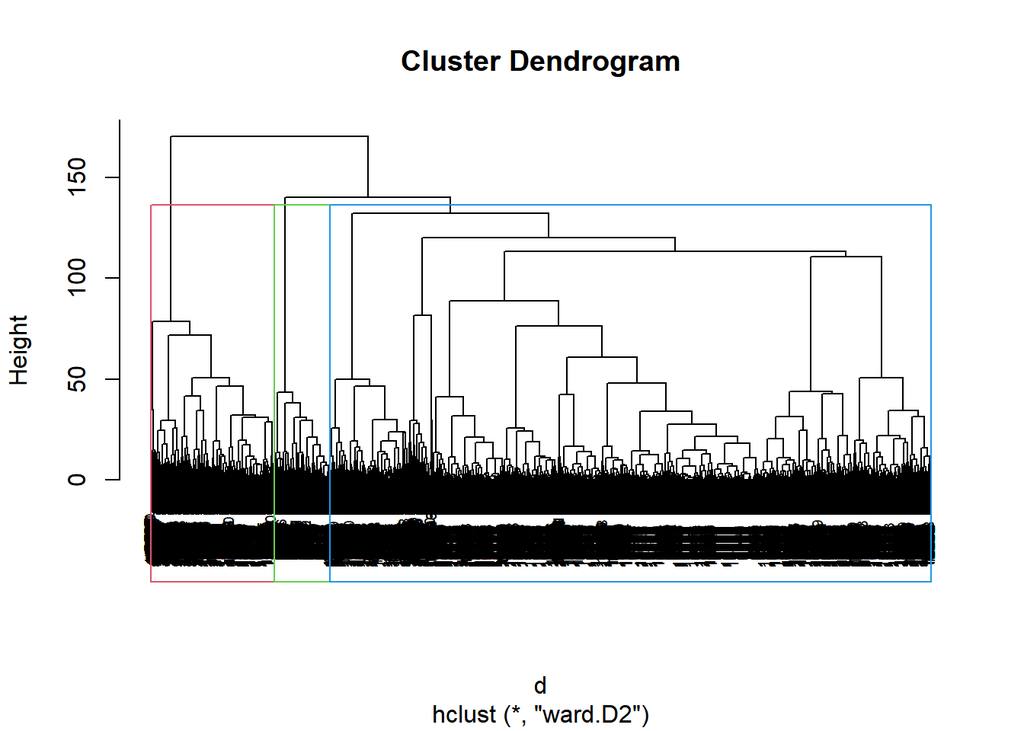

```r
plot(hc, cex = 0.6)
rect.hclust(hc, k = 3, border = 2:5)
```

# Challenging the Solution

challenge the solution using in hierarchical clustering using method set at average

```r
clusters1 <- hclust(dist(online.norm),method="average")
plot(clusters)
```

[output not shown]

```r
cut <- cutree(clusters1, 10)
table(cut,online.class)
```

```
##     online.class
## cut      0     1
##   1  10246  1788
##   2     12    90
##   3      2    11
##   4      2     1
##   5     35    12
##   6      1     1
##   7      5     2
##   8      0     1
##   9      0     1
##   10     0     1
```

# Follow up Questions

- Kmeans clustering is preferred for this type of dataset due its dimensions, kmeans also produced higher clusters that are slightly distinguishable from the visualization compared to Hierarchical clustering
- However, kmeans requires that the clusters to be predetermined, and it was difficult to determine the number of clusters for optimization. It was a tie between 2 and 3. Kmeans is also sensitive to scaling data, data needs to be scaled first so that all variables are equally used during clustering.